# Problem 1

Find the vertical asymptotes, holes, and horizontal asymptotes of

$\huge \frac{x-3}{(x^2-9)(x-2)} $

```python
f = (x-3)/((x^2-9)*(x-2))
```

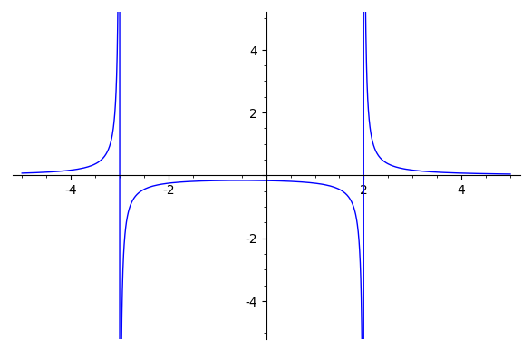

```python
plot(f, (x, -5, 5), ymin=-5, ymax=5)
```

As we can see above, there are two vertical asymptotes: one at $x = -3$ and one at $x = 2$. One may be tempted to conclude that $x=3$ is an asymptote as well, but this leads to a 0/0, so as the code below shows, there is actually a hole there. In particular, evaluating this will lead to a division by zero

```python
f(3)
```

[output not shown]

# Problem 2

Find the following limit

$ \huge \lim_{x \to -\infty} \frac{5 x^3 - 4 x^2 + 3x + 4}{4x^2 + 10x - 1} $

```python
f = (5*x^3 - 4*x^2 + 3*x + 4)/(4*x^2 + 10*x - 1)
```

```python
N(f(-1000000))
```

```
-1.25000412501137e6
```

There are some vertical asymptotes near the origin, but if we zoom out enough, we actually see that the function is growing towards $+\infty$ as we go to the right, and towards $-\infty$ as we go to the left

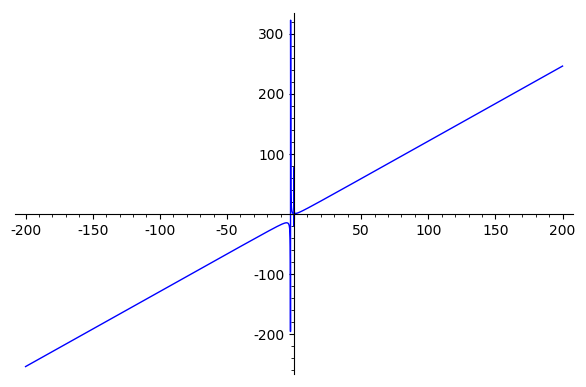

```python
plot(f, (x, -200, 200))
```

# Problem 3

Find the following limit

$ \huge \lim_{x \to \infty} \frac{3 x^4 - x^3 + 2}{9x^2 - 9x^4 + 3x} $

In this case, the leading terms in the numerator and denominator are of the same degree (degree 4), so we can simply divided their coefficients and ignore everything else, since they dominate. So the final answer is $3/-9 = -1/3$ for both limits towards $\infty$ and $-\infty$

```python
f = (3*x^4 - x^3 + 2)/(9*x^2 - 9*x^4 + 3*x)
```

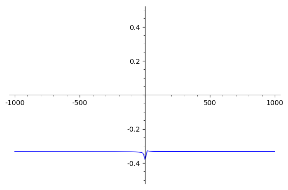

```python
plot(f, (x, -1000, 1000), ymin=-0.5, ymax=0.5)
```

# Problem 4

Find the following limit

$ \huge \lim_{x \to \infty} \frac{\sin(10x)}{12x} $

In this case, we can use the squeeze theorem to define two other functions, $h(x) = \frac{-1}{12x}$ and $g(x) = \frac{1}{12x}$ so that $\h(x) \leq f(x) \leq g(x)$ and $\lim_{x \to \infty} h(x) = \lim_{x \to \infty} g(x) = 0$

```python
f = sin(10*x)/(12*x)
h = -1/(12*x)
g = 1/(12*x)
```

```python
p1 = plot(f, (x, 0, 5), ymin=-1, ymax=1, color='blue', legend_label='$f(x)$')
p2 = plot(h, (x, 0, 5), ymin=-1, ymax=1, color='red', legend_label='$h(x)$')
p3 = plot(g, (x, 0, 5), ymin=-1, ymax=1, color='green', legend_label='$g(x)$')
```

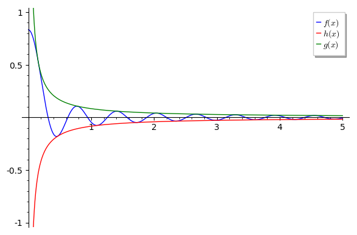

```python
show(p1+p2+p3)
```

# Problem 5

Find the horizontal asymptotes of the following function

$\huge f(x) = \frac{3 x^3 + x}{4 x^3 - x^2 + |x^3|} $

We should redefine this function separately for positive $x$ and negative $x$. In particular, we can write

$\huge f(x) = \left\{ \begin{array}{cc} \frac{3 x^3 + x}{4 x^3 - x^2 + x^3}, & x > 0 \\ \frac{3 x^3 + x}{4 x^3 - x^2 - x^3}, & x < 0 \end{array} \right\} $

Using the fact that

$ |x^3| = \left\{ \begin{array}{cc} x^3, & x > 0 \\ -x^3, & x < 0 \end{array} \right\} $

This means that $\lim_{x \to \infty} f(x) = 3/5$ and $\lim_{x \to -\infty} f(x) = 1$

```python
f = (3*x^3 + x)/(4*x^3 - x^2 + abs(x^3))
```

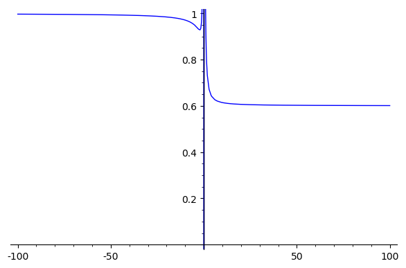

```python
plot(f, (x, -100, 100), ymin=0, ymax=1)
```

# Problem 6

Find the horizontal asymptotes of the following function

$\Large f(x) = \frac{4 x^5}{\sqrt{x^{10} - 4x^2}} $

If we look at $ \lim_{x \to \infty} f(x)$ then the $x^{10}$ term in the denominator wins over, so we can just look at

$\Large \lim_{x \to \infty} \frac{4 x^5}{\sqrt{x^{10}}} = \lim_{x \to \infty} \frac{4 x^5}{|x^5|}$

This is using the fact that $\sqrt{a^2} = |a|$ (you can check this fact with some examples, or just memorize the rule). Therefore, we have that

$\Large \lim_{x \to \infty} f(x) = \lim_{x \to \infty} \frac{4 x^5}{x^5} = 4$

and that

$\Large \lim_{x \to -\infty} f(x) = \lim_{x \to -\infty} \frac{4 x^5}{-x^5} = -4$

We verify below that the horizontal asymptotes are at $y = -4$, $y = 4$

```python
f = (4*x^5)/(sqrt(x^10 - 4*x^2))
```

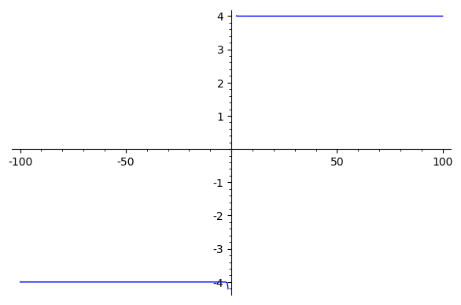

```python
plot(f, (x, -100, 100))
```